# Linear Models I

If the system prompts you to install a package, or gives you a “package not found” error, simply run `install.packages("packagename")` once to install it.

# The Dataset

Today we will use a dataset containing counts of babies born in California with the name “Kelly” between 1989 and 2016. Run the chunk below to load the data, and to check out the first few rows of your dataset.

```r
kelly_df <- read_csv("https://www.dropbox.com/s/p3dez3ug5fquygh/kellys_ca.csv?dl=1")
head(kelly_df)
```

```
## # A tibble: 6 x 5
##   State Gender  Year Name  Count
##   <chr> <chr>  <dbl> <chr> <dbl>
## 1 CA    F       1989 Kelly   920
## 2 CA    F       1990 Kelly   929
## 3 CA    F       1991 Kelly   785
## 4 CA    F       1992 Kelly   800
## 5 CA    F       1993 Kelly   703
## 6 CA    F       1994 Kelly   682
```

The first thing we need to do with any dataset is check for missing data, and make sure the variables are the right type:

```r
kelly_df %>% summary()
```

```
##     State              Gender               Year          Name
##  Length:56          Length:56          Min.   :1989   Length:56
##  Class :character   Class :character   1st Qu.:1996   Class :character
##  Mode  :character   Mode  :character   Median :2002   Mode  :character
##                                        Mean   :2002
##                                        3rd Qu.:2009
##                                        Max.   :2016
##      Count
##  Min.   :  9.0
##  1st Qu.: 20.0
##  Median : 97.5
##  Mean   :238.0
##  3rd Qu.:445.2
##  Max.   :929.0
```

Looks good for this data, with one exception:

The “Gender” variable is being treated as a “character” variable, i.e., just an ordinary word.

But we know it should be *categorical*, aka a *factor* variable. Let’s `mutate` the dataset to fix this:

```r
kelly_df <- kelly_df %>%
  mutate(
    Gender = factor(Gender)
  )

kelly_df %>% summary()
```

```
##     State           Gender      Year          Name               Count
##  Length:56          F:28   Min.   :1989   Length:56          Min.   :  9.0
##  Class :character   M:28   1st Qu.:1996   Class :character   1st Qu.: 20.0
##  Mode  :character          Median :2002   Mode  :character   Median : 97.5
##                            Mean   :2002                      Mean   :238.0
##                            3rd Qu.:2009                      3rd Qu.:445.2
##                            Max.   :2016                      Max.   :929.0
```

The next thing we should do is visualize our variables to get a feel for what is going on in this data.

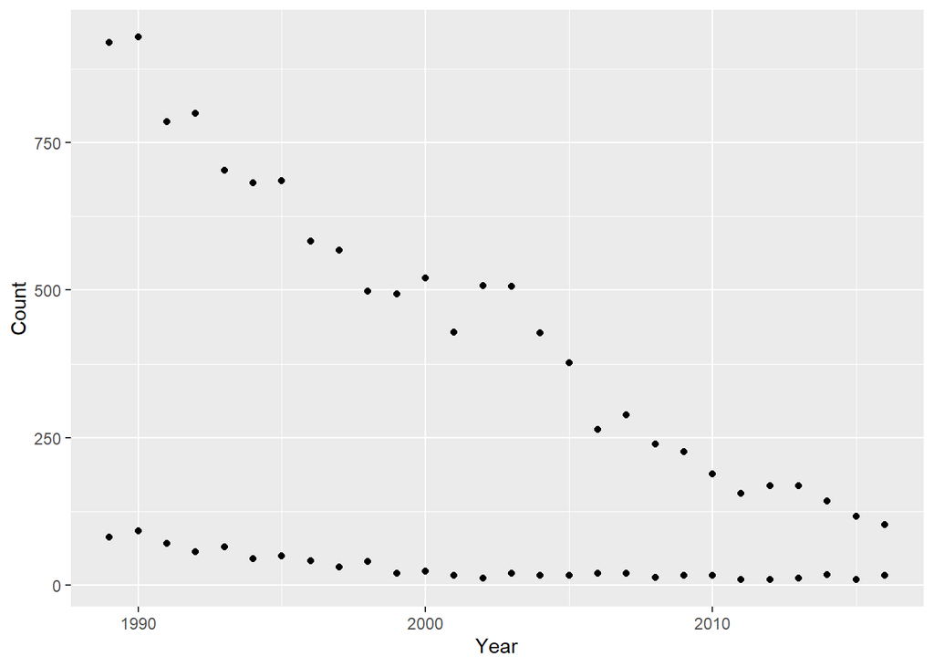

```r
kelly_df %>%
  ggplot(aes(x = Year, y = Count)) +
  geom_point()
```

Hmmm…. clearly there is some kind of linear-ish decreasing trend in number of Kellys. But what’s going on with the two separate lines?

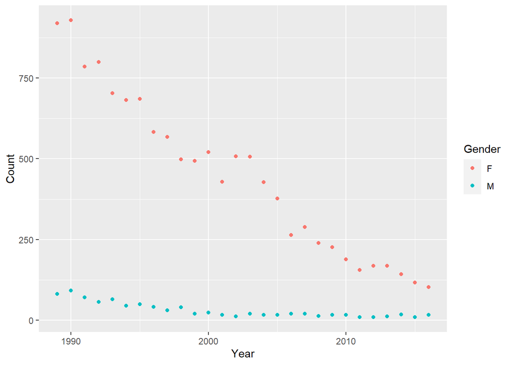

```r
kelly_df %>%
  ggplot(aes(x = Year, y = Count, color = Gender)) +
  geom_point()
```

## Fitting a model

Let’s begin with a simple linear model. We will focus only on the female-assigned Kelly babies for now.

```r
kellys_fem <- kelly_df %>%
  filter(
    Gender == "F"
  )
```

Our first step is to establish a which model(s) we want to try on the data.

For now, this is just a simple linear model.

To establish the model, we need to determine which R package it comes from (the “engine”) and whether we are doing *regression* or *classification*.

(These functions come from the *tidymodels* package that we loaded in the setup chunk.)

```r
lin_reg <- linear_reg() %>%
  set_engine("lm") %>%
  set_mode("regression")
```

Next, we will **fit** the model to our data:

```r
lin_reg_fit <- lin_reg %>%
  fit(Count ~ Year, data = kellys_fem)
```

Let’s check out the output of this model fit:

```r
lin_reg_fit$fit %>%
  summary()
```

```
##
## Call:
## stats::lm(formula = Count ~ Year, data = data)
##
## Residuals:
##     Min      1Q  Median      3Q     Max
## -82.389 -37.288  -2.308  40.127 108.871
##
## Coefficients:
##              Estimate Std. Error t value Pr(>|t|)
## (Intercept) 60455.320   2387.585   25.32   <2e-16 ***
## Year          -29.967      1.192  -25.13   <2e-16 ***
## ---
## Signif. codes:  0 '***' 0.001 '**' 0.01 '*' 0.05 '.' 0.1 ' ' 1
##
## Residual standard error: 50.96 on 26 degrees of freedom
## Multiple R-squared:  0.9605, Adjusted R-squared:  0.9589
## F-statistic: 631.7 on 1 and 26 DF,  p-value: < 2.2e-16
```

How do we interpret this?

- The slope is -29.97. That means there are about 30 fewer female babies named Kelly born each year since 1989!
- The p-value of the model is basically 0. That means this model is very significant, i.e., there is probably a relationship between the variables.
- The r-squared value is 0.9605. This means 96.05% of the variance in Kelly names over the years is explained by the name going out of style as time passes.

## Residuals

Now let’s look the residuals of the model.

First, we can find out what values were predicted by the model:

```r
preds <- lin_reg_fit %>%
  predict(new_data = kellys_fem)
```

Then, we can calculate and visualize the residuals:

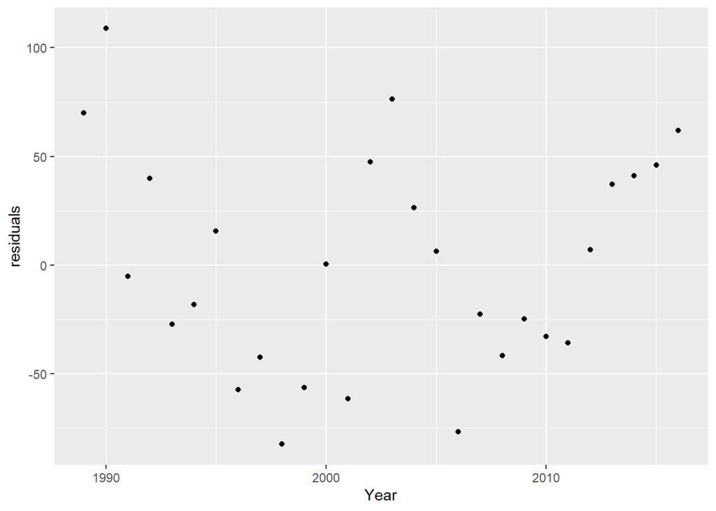

```r
kellys_fem <- kellys_fem %>%
  mutate(
    Predicted_Count = preds$.pred,
    residuals = Count - Predicted_Count
  )

kellys_fem %>%
  ggplot(aes(x = Year, y = residuals)) +
    geom_point()
```

Do the residuals seem to represent “random noise”?

That is, was our choice of model reasonable?

## Metrics

If we are trying to find the “best” model, we should measure how well this one did.

We can compute the SSE and MSE “by hand”:

```r
sum(kellys_fem$residuals^2)
```

```
## [1] 67527.03
```

```r
mean(kellys_fem$residuals^2)
```

```
## [1] 2411.68
```

# YOUR TURN

What about Gender? Is the pattern of decreasing Kelly babies the same for the two Genders? Can you include Gender in the model, and interpret the results?

With your group, create a new notebook (you can copy this one if you want), and fit a model using both Year *and* Gender as predictors. Report your results.